# Rugema_UHG_Capstone

## Project Description

### Topic:

**Influences on Childhood Outcomes: Identifying the Greatest Risk Factors for Teen Birth Rates**

### Research Question(s):

- What are the key risk factors associated with higher teen birth rates across U.S. counties?
- How do socioeconomic and health-related factors influence adolescent pregnancies?

### Importance:

Teen birth rates have significant social, economic, and health impacts on both the adolescents and their communities. Identifying the most influential risk factors can help public health officials, educators, and policymakers design targeted interventions to reduce adolescent pregnancies and support better outcomes for young people.

## Data Preparation

```python
import pandas as pd
import numpy as np
import seaborn as sns
import matplotlib.pyplot as plt
import plotly.express as px
from sklearn.preprocessing import StandardScaler
from sklearn.decomposition import PCA
from sklearn.cluster import KMeans
from sklearn.mixture import GaussianMixture
from sklearn.tree import DecisionTreeClassifier, plot_tree
```

```python
data = pd.read_csv("./analytic_data2025_v2.csv", low_memory=False)
```

```python
# Select relevant columns for our analysis
selected_columns = ['State Abbreviation', 'Name', 'Life Expectancy raw value', 'Food Insecurity raw value',
                    'Children in Poverty raw value', 'Some College raw value', 'Food Environment Index raw value',
                    'High School Completion raw value', 'Broadband Access raw value', 'Uninsured Adults raw value',
                    'Teen Births raw value']

# New filtered dataframe
data_subset = data[selected_columns].copy()

# Rename columns for clarity
data_subset.rename(columns={
    'State Abbreviation': 'state',
    'Name': 'county',
    'Life Expectancy raw value': 'life_expectancy',
    'Food Insecurity raw value': 'food_insecurity',
    'Children in Poverty raw value': 'children_in_poverty',
    'Some College raw value': 'some_college',
    'Food Environment Index raw value': 'food_environment',
    'High School Completion raw value': 'high_school_completion',
    'Broadband Access raw value': 'broadband_access',
    'Uninsured Adults raw value': 'uninsured_adult',
    'Teen Births raw value': 'teen_birth_rate'
}, inplace=True)

# Remove the first row
data_subset.drop(index=0, inplace=True)
data_subset.reset_index(drop=True, inplace=True)
```

## Basic Info & Cleaning

```python
data_subset.head()
```

|  | state | county | life_expectancy | food_insecurity | children_in_poverty | some_college | food_environment | high_school_completion | broadband_access | uninsured_adult | teen_birth_rate |
| --- | --- | --- | --- | --- | --- | --- | --- | --- | --- | --- | --- |
| 0 | US | United States | 77.099412282 | 0.135 | 0.16 | 0.6782543655 | 7.4 | 0.8939293324 | 0.8971186991 | 0.1123892209 | 15.536374441 |
| 1 | AL | Alabama | 73.279289325 | 0.174 | 0.213 | 0.6177276981 | 5.3 | 0.8812804099 | 0.8561986283 | 0.1329018619 | 23.706832713 |
| 2 | AL | Autauga County | 74.800645825 | 0.151 | 0.17 | 0.6137873219 | 6.8 | 0.9027890205 | 0.9088043333 | 0.1034935718 | 19.846153846 |
| 3 | AL | Baldwin County | 76.580109234 | 0.149 | 0.141 | 0.6484787528 | 7.4 | 0.9173139987 | 0.8975085057 | 0.1270583015 | 18.970019847 |
| 4 | AL | Barbour County | 72.708991709 | 0.19 | 0.348 | 0.4407743125 | 6.2 | 0.7781370547 | 0.7230176211 | 0.1580139227 | 35.930645498 |

```python
# Select variables for conversion
numeric_cols = ['life_expectancy', 'food_insecurity', 'children_in_poverty', 'some_college',
                'food_environment', 'high_school_completion', 'broadband_access', 'uninsured_adult',
                'teen_birth_rate']

# Get the columns to convert
data_subset[numeric_cols] = data_subset[numeric_cols].apply(pd.to_numeric, errors='coerce')
data_subset.info()
```

```
<class 'pandas.core.frame.DataFrame'>
RangeIndex: 3204 entries, 0 to 3203
Data columns (total 11 columns):
 #   Column                  Non-Null Count  Dtype
---  ------                  --------------  -----
 0   state                   3204 non-null   object
 1   county                  3204 non-null   object
 2   life_expectancy         3120 non-null   float64
 3   food_insecurity         3196 non-null   float64
 4   children_in_poverty     3195 non-null   float64
 5   some_college            3195 non-null   float64
 6   food_environment        3152 non-null   float64
 7   high_school_completion  3196 non-null   float64
 8   broadband_access        3196 non-null   float64
 9   uninsured_adult         3195 non-null   float64
 10  teen_birth_rate         2961 non-null   float64
dtypes: float64(9), object(2)
memory usage: 275.5+ KB
```

```python
# Imputing missing values with the mean of the column
data_subset[numeric_cols] = data_subset[numeric_cols].fillna(data_subset[numeric_cols].mean())
data_subset.isnull().sum()
```

```
state                     0
county                    0
life_expectancy           0
food_insecurity           0
children_in_poverty       0
some_college              0
food_environment          0
high_school_completion    0
broadband_access          0
uninsured_adult           0
teen_birth_rate           0
dtype: int64
```

```python
data_subset.describe()
```

|  | life_expectancy | food_insecurity | children_in_poverty | some_college | food_environment | high_school_completion | broadband_access | uninsured_adult | teen_birth_rate |
| --- | --- | --- | --- | --- | --- | --- | --- | --- | --- |
| count | 3204.000000 | 3204.000000 | 3204.000000 | 3204.000000 | 3204.000000 | 3204.000000 | 3204.000000 | 3204.000000 | 3204.000000 |
| mean | 75.171058 | 0.143846 | 0.189321 | 0.593299 | 7.452824 | 0.887942 | 0.844283 | 0.122990 | 21.806543 |
| std | 3.564374 | 0.034553 | 0.080087 | 0.116727 | 1.192567 | 0.054423 | 0.065491 | 0.055919 | 10.769740 |
| min | 53.980813 | 0.058000 | 0.031000 | 0.168058 | 0.000000 | 0.468085 | 0.481383 | 0.024813 | 1.459083 |
| 25% | 72.901328 | 0.119000 | 0.130000 | 0.516539 | 6.800000 | 0.857186 | 0.811378 | 0.079300 | 14.090462 |
| 50% | 75.181319 | 0.141000 | 0.178000 | 0.593531 | 7.600000 | 0.899177 | 0.853407 | 0.110773 | 21.533791 |
| 75% | 77.490090 | 0.166000 | 0.232250 | 0.675148 | 8.300000 | 0.927475 | 0.889444 | 0.156946 | 27.853173 |
| max | 94.218993 | 0.288000 | 0.632000 | 0.932070 | 10.000000 | 1.000000 | 1.000000 | 0.407318 | 95.238095 |

## Exploratory Data Analysis (EDA)

```python
sns.set(style='whitegrid')
```

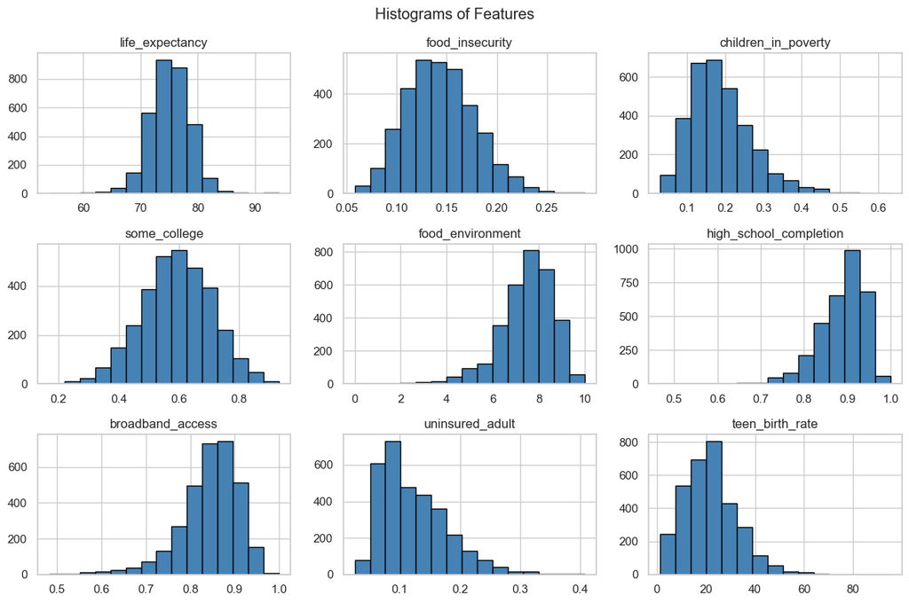

```python
# Histogram of all the numeric to understand how some variables are distributed
data_subset[numeric_cols].hist(bins=15, figsize=(12, 8), color='#4682B4', edgecolor='black')
plt.suptitle('Histograms of Features')
plt.tight_layout()
plt.show()
```

### Observation of Histograms

Most features appear to be approximately normally distributed with slight skewness:

- **Life Expectancy** and **Some College** show symmetric, bell-shaped distributions.
- **Food Insecurity**, **Children in Poverty**, **Uninsured Adults**, and **Teen Birth Rate** are right-skewed, indicating that most counties have lower rates, but some experience significantly higher rates.
- **Food Environment**, **High School Completion**, and **Broadband Access** are left-skewed, suggesting most counties perform well on these indicators, but a few have much lower access or outcomes.

Overall, these distributions highlight regional disparities in social, economic, and health conditions.

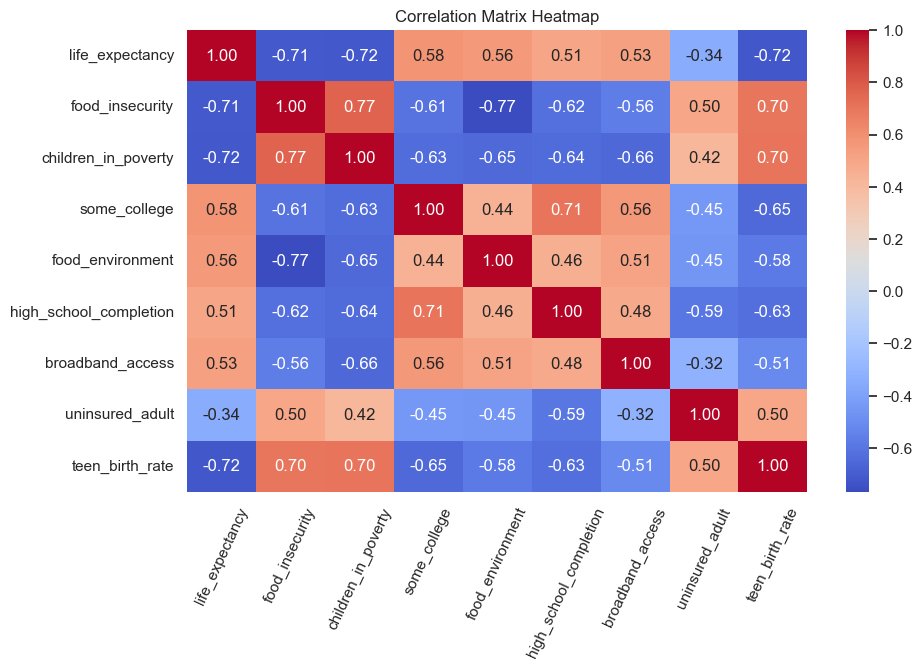

```python
# Visualize the correlation matrix
plt.figure(figsize=(10, 6))
sns.heatmap(data_subset.corr(numeric_only=True), annot=True, cmap='coolwarm', fmt='.2f')
plt.title('Correlation Matrix Heatmap')
plt.xticks(rotation=65)
plt.show()
```

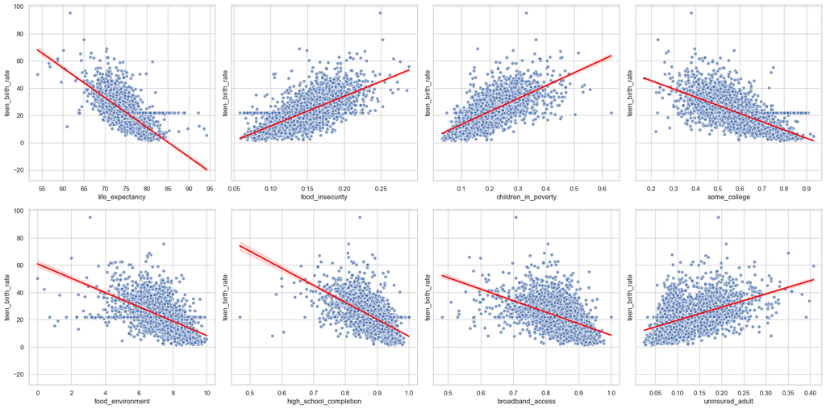

```python
# Variables to plot against teen_birth_rate
x_vars = ['life_expectancy', 'food_insecurity', 'children_in_poverty', 'some_college',
          'food_environment', 'high_school_completion', 'broadband_access', 'uninsured_adult']

y_var = 'teen_birth_rate'

# Set up 2 rows and 4 columns
fig, axes = plt.subplots(2, 4, figsize=(20, 10), sharey=True)

# Flatten the axes array for easy iteration
axes = axes.flatten()

# Plot each scatterplot with regression line
for i, var in enumerate(x_vars):
    sns.regplot(data=data_subset, x=var, y=y_var, ax=axes[i], scatter_kws={'alpha':0.7, 'edgecolor':'white'}, line_kws={'color':'red'})
plt.tight_layout()
plt.show()
```

### Observation of Scatter Plots and Correlations

The scatter plots reveal clear linear relationships between teen birth rate and several factors:

- **Negative Correlations:** Higher life expectancy, some college education, food environment index, high school completion, and broadband access are all associated with lower teen birth rates.
- **Positive Correlations:** Higher food insecurity, children in poverty, and uninsured adults are linked to higher teen birth rates.

These patterns suggest that improving socioeconomic and health conditions may contribute to reducing adolescent pregnancies.

### Unsupervised Learning Analysis

#### Principal Component Analysis

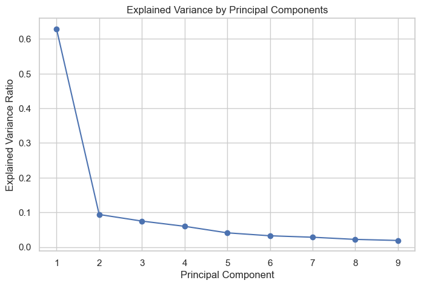

```python
# Select features
features = data_subset.drop(columns=['state', 'county'])
scaled_features = StandardScaler().fit_transform(features)

# Apply PCA
pca = PCA()
pca_result = pca.fit_transform(scaled_features)

# Create a scree plot to show explained variances
plt.figure(figsize=(8,5))
plt.plot(range(1, len(pca.explained_variance_ratio_)+1),
        pca.explained_variance_ratio_, marker='o', linestyle='-')
plt.title('Explained Variance by Principal Components')
plt.xlabel('Principal Component')
plt.ylabel('Explained Variance Ratio')
plt.show()
```

### K-Means clustering

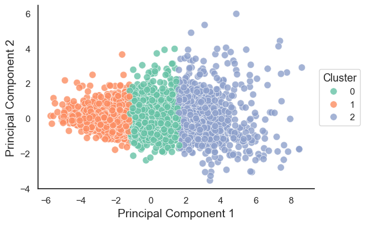

```python
# Reduce to 2 PC for visualization
pca = PCA(n_components=2)
pca_components = pca.fit_transform(scaled_features)

# Apply K-Means clustering
kmeans = KMeans(n_clusters=3, random_state=42)
clusters = kmeans.fit_predict(pca_components)

# Create a DataFrame for plotting
pca_df = pd.DataFrame(pca_components, columns=['PC1', 'PC2'])
pca_df['Cluster'] = clusters

sns.set_style('white')

# Create a plot to show the clusters
plt.figure(figsize=(6,4))
sns.scatterplot(data=pca_df, x='PC1', y='PC2', hue='Cluster', palette='Set2', s=70, alpha=0.8, edgecolor='white', linewidth=0.5)
plt.xlabel('Principal Component 1', fontsize=14)
plt.ylabel('Principal Component 2', fontsize=14)
plt.grid(False)
sns.despine()
plt.legend(title = 'Cluster', loc='center left', bbox_to_anchor=(1, 0.5), title_fontsize='13', fontsize='11')
plt.show()
```

### Gaussian Mixture Model

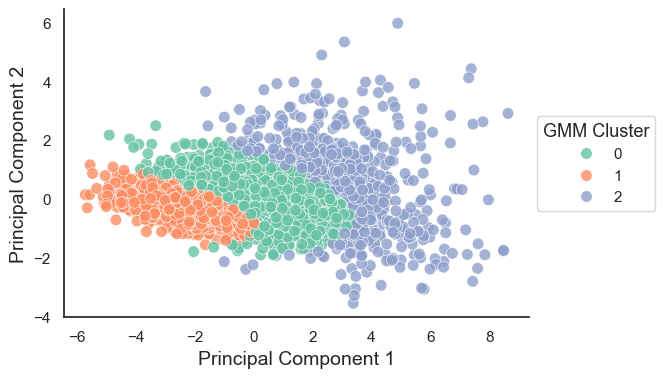

```python
# Fit GMM with 3 components (clusters)
gmm = GaussianMixture(n_components=3, random_state=42)
gmm.fit(pca_components)

# Predict the most probable cluster for each county
gmm_clusters = gmm.predict(pca_components)

# Create a DataFrame for plotting
pca_df['GMM Cluster'] = gmm_clusters

# Create a plot to show the clusters
plt.figure(figsize=(6, 4))
sns.scatterplot(data=pca_df, x='PC1', y='PC2', hue='GMM Cluster', palette='Set2', s=70, alpha=0.8, edgecolor='white', linewidth=0.5)
plt.xlabel('Principal Component 1', fontsize=14)
plt.ylabel('Principal Component 2', fontsize=14)
plt.grid(False)
sns.despine()
plt.legend(title='GMM Cluster', loc='center left', bbox_to_anchor=(1, 0.5), title_fontsize='13', fontsize='11')
plt.show()
```

```python
# Add Cluster to the full dataset
data_subset['Cluster'] = gmm_clusters

# Select only numeric columns + Cluster
numeric_cols = ['life_expectancy', 'food_insecurity', 'children_in_poverty', 'some_college',
                'food_environment', 'high_school_completion', 'broadband_access', 'uninsured_adult',
                'teen_birth_rate', 'Cluster']

# Group by Cluster and compute means
cluster_summary = data_subset[numeric_cols].groupby('Cluster').mean().round(2)

cluster_summary
```

| Cluster | life_expectancy | food_insecurity | children_in_poverty | some_college | food_environment | high_school_completion | broadband_access | uninsured_adult | teen_birth_rate |
| --- | --- | --- | --- | --- | --- | --- | --- | --- | --- |
| 0 | 74.46 | 0.15 | 0.20 | 0.57 | 7.30 | 0.88 | 0.84 | 0.13 | 23.23 |
| 1 | 77.49 | 0.12 | 0.13 | 0.69 | 8.21 | 0.93 | 0.88 | 0.08 | 13.77 |
| 2 | 72.21 | 0.18 | 0.28 | 0.47 | 6.32 | 0.81 | 0.79 | 0.19 | 34.50 |

### Observation of Cluster Profiles

The cluster profiles show distinct patterns across key features:

- **Cluster 1 (Orange)** consistently shows the most favorable conditions: the highest life expectancy, lowest food insecurity, lowest children in poverty, highest education attainment (both some college and high school completion), best food environment, highest broadband access, lowest uninsured adult rate, and the lowest teen birth rate.
- **Cluster 0 (Green)** tends to fall in between Clusters 1 and 2 across most features.
- **Cluster 2 (Blue)** generally reflects the least favorable conditions: lowest life expectancy, highest food insecurity, highest poverty levels, lowest education attainment, poorest food environment, lowest broadband access, highest uninsured adult rate, and the highest teen birth rate.

These patterns suggest that counties in Cluster 1 enjoy stronger socioeconomic and health-related advantages, which may contribute to their lower rates of adolescent pregnancies.

### Decision Tree Model

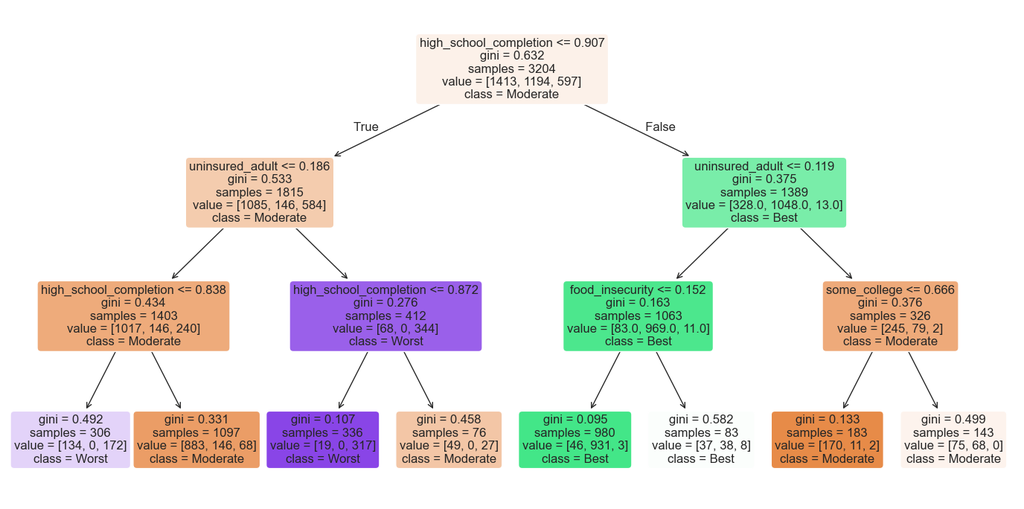

```python
X = features  # Original features
y = gmm_clusters  # predicted labels from GMM

tree = DecisionTreeClassifier(max_depth=3, random_state=42)
tree.fit(X, y)

plt.figure(figsize=(14, 7))
plot_tree(
    tree,
    feature_names=X.columns,
    class_names=['Moderate', 'Best', 'Worst'],
    filled=True,
    impurity=True,
    fontsize=12,
    rounded=True
)
plt.tight_layout()
plt.show()
```

### Observation of the Tree Model

The decision tree was applied to visualize which features drive the assignment of counties into GMM clusters based on their health and socioeconomic profiles. The root of the tree splits on **high school completion**, making it the most important factor for determining cluster membership. Counties with **lower high school completion rates (< 90.7%)** are more likely to fall into the "Moderate" or "Worst" clusters, while those above this threshold tend to belong to the "Best" cluster.

As we move down the tree, additional splits on **uninsured adult rates**, **food insecurity**, and **some college education** further separate counties. For example, counties with **low high school completion and high uninsured rates (> 18.6%)** are often classified in the “Worst” cluster (purple nodes). Conversely, counties with **high school completion above 90.7%**, **low uninsured rates (< 11.9%)**, and **low food insecurity (< 15.2%)** tend to belong to the “Best” cluster (green nodes).

This tree helps identify the most influential social determinants behind cluster membership and reveals clear pathways through which conditions like education, health insurance coverage, and food access influence teen birth outcomes across the U.S.

```python
# Prepare the data
map_data = data.iloc[1:].copy().reset_index(drop=True)
map_data['Cluster'] = gmm_clusters

# FIPS codes must be string, padded to 5 digits
map_data['FIPS'] = map_data['5-digit FIPS Code'].astype(str).str.zfill(5)

# Create a choropleth map
fig = px.choropleth(map_data,
                    geojson='https://raw.githubusercontent.com/plotly/datasets/master/geojson-counties-fips.json',
                    locations='FIPS',
                    color='Cluster',
                    scope='usa',
                    hover_name='Name',
                    color_discrete_sequence=px.colors.qualitative.Set2)
fig.update_layout(margin={"r":0,"t":50,"l":0,"b":0}, coloraxis_colorbar={'x': 0.8})
fig.show()
```

[interactive chart not shown]

### Observation of Geographical Distribution

The geographical distribution map shows clear spatial patterns in the clustering of counties across the United States:

- **Cluster 1 (shown in pink/red)**: Predominantly found in the northern, northeastern, and some western regions. These counties generally have the most favorable socioeconomic and health-related conditions, as previously observed.
- **Cluster 2 (shown in yellow)**: Concentrated mainly in the southern states, parts of the southwest, and pockets of Alaska. These areas tend to have the least favorable conditions, including higher teen birth rates, lower education levels, and higher poverty.
- **Cluster 0 (shown in dark blue)**: Distributed across the country but with significant presence in the Midwest, Mountain West, and parts of the West Coast. These counties tend to fall between the other two clusters in terms of socioeconomic and health indicators.

The map visually reinforces regional disparities in factors influencing teen birth rates, suggesting that interventions may need to be tailored by region.